# Final Project

Alyson DeNittis

April 27, 2018

## Project Background

The data for this analysis comes from an experiment attempting to propagate a threatened plant species from tissue explants using plant tissue culture techniques. One component of data collection for this project is quantifying the average size of plantlets weekly in order to evaluate growth rate over time in response to 9 treatments. ImageJ analysis software is used to calculate the surface area of 2 aspects of each plantlet. The sum of these 2 area values is assigned to each observation as a quantitative measure of size.

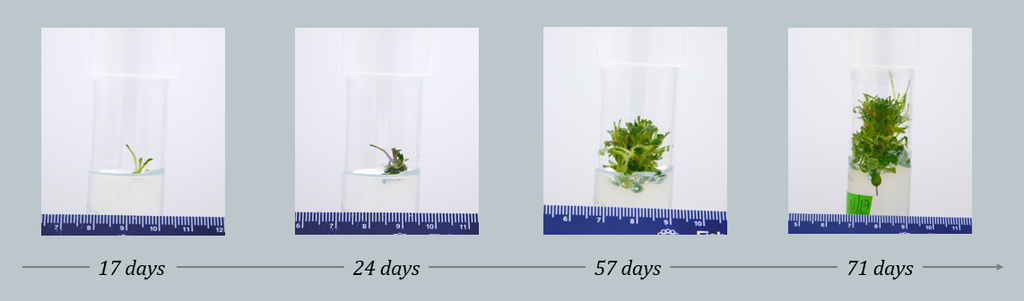

Figure 1. Plantlet images at various ages from same aspect.

## Data

The following is a sample of the raw experimental data:

```
##         Date Initials Grp  ID Img.V1 Img.V2 RT CV V1.Area..cm.2.
## 1  1/16/2018       AD   M 154   1931   1932  S  0        0.16667
## 2  1/16/2018       AD   M 199   2109   2110  S  0        1.00496
## 3  1/16/2018       AD   M 244   2107   2108  S  0        0.21029
## 4  1/16/2018       AD   M 225   2105   2106  S  0        0.88290
## 5  1/16/2018       AD   M 246   2103   2104  S  0        0.70217
## 6  1/16/2018       AD   M 195   2101   2102  S  0        0.98462
## 7  1/16/2018       AD   M 211   2099   2100  S  0        0.19805
## 8  1/16/2018       AD   M 212   2097   2098  S  0        0.28614
## 9  1/16/2018       AD   M 192   2095   2096  S  0        0.05109
## 10 1/16/2018       AD   M 204   2093   2094  S  0        0.36002
##    V2.Area..cm.2. C.N CONT Root Notes
## 1         0.15856   1    0    0
## 2         0.89799   1    0    0
## 3         0.72447   1    0    0
## 4         0.65869   2    0    0
## 5         0.77238   0    0    0
## 6         1.12660   2    0    0
## 7         0.22404   1    0    0
## 8         0.31904   2    0    0
## 9         0.02501   2    0    0
## 10        0.33112   1    0    0
```

There are multiple fields that are not necessary for this portion of the analysis, and the data needs to be converted to a usable format:

- Add column with area value sums
- Assign treatments
- Subset to columns for analysis (mostly for aesthetic purposes)
- Dates converted to proper format required for time series analysis
- Other cleaning

For the purposes of this project and coercion for use with specific packages, a new data set was modeled after the raw data to show the steps of analysis.The following is a sample of the dataframe used for this analysis.

New data frame for analysis:

```
##     X Age_wk Treatment ID    Sum_area
## 1   1      1         1  1 0.003463195
## 2   2      1         1  2 0.001096696
## 3   3      1         1  3 0.003896433
## 4   4      1         1  4 0.001964567
## 5   5      1         1  5 0.004903355
## 6   6      1         1  6 0.004577003
## 7   7      1         1  7 0.002053009
## 8   8      1         1  8 0.002024783
## 9   9      1         1  9 0.003253029
## 10 10      1         1 10 0.004679688
```

## Analysis

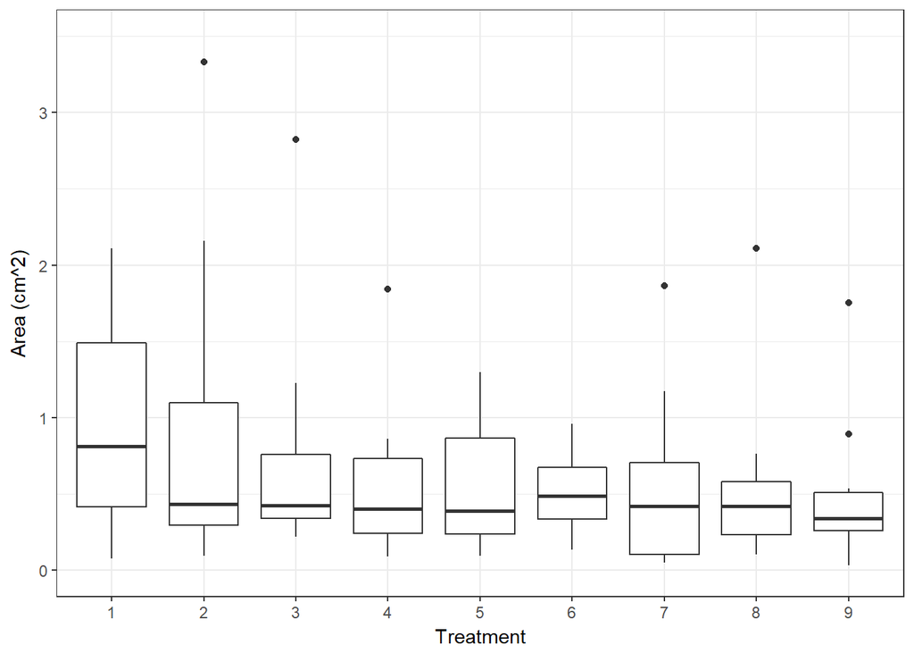

**Summary Statistics**

```
## # A tibble: 9 x 4
##   Treatment count  mean    sd
##       <dbl> <int> <dbl> <dbl>
## 1        1.    12 0.964 0.662
## 2        2.    11 0.895 1.04
## 3        3.    10 0.738 0.795
## 4        4.    11 0.564 0.498
## 5        5.    12 0.548 0.436
## 6        6.    11 0.966 1.51
## 7        7.    10 0.553 0.582
## 8        8.    12 1.35  2.84
## 9        9.    12 0.486 0.452
```

Graph showing mean with standard errors, with a jitter applied to data points.

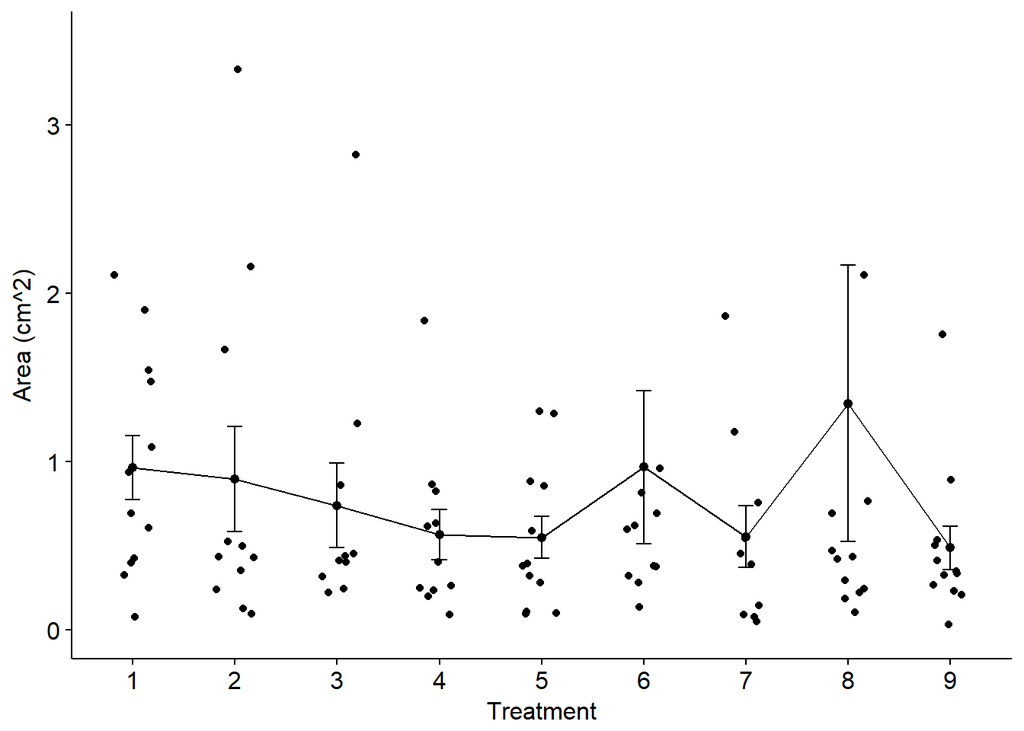

**One-Way ANOVA**

```
##             Df Sum Sq Mean Sq F value Pr(>F)
## Treatment    1   0.05  0.0465   0.031  0.862
## Residuals   99 150.51  1.5203
```

Based on the results from the ANOVA, there does not to be a statistically significant difference in mean size of plantlets between treatment groups. Although there does not seem to be a correlation between plant size and growth treatments, this particular subset of the experimental data can be used to analyze several other things.

**Growth Rate Over Time**

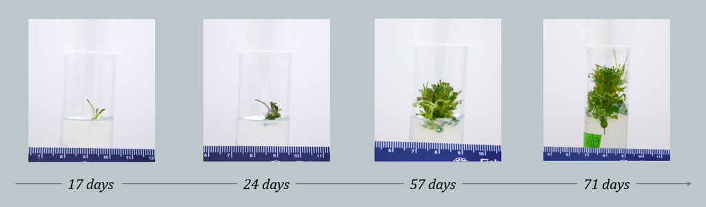

Plantlet images at various ages from same aspect.

Tissue for this experiment is cultured on media augmented with various nutrients and growth hormones. The tissue then has to be continuously subcultured on fresh media for the duration of *in vitro* growth as nutrients and moisture is depleted. As they do, plantlet vigor starts to decrease. This may result in reduced growth rate, and possibly a reduction in size as plantlets start to die back or dessicate. Determining the growth rate for each treatment observed every 7 days can help to capture and detect these changes to determine ideal times for subculturing (along with other data collected that is not being used in this analysis).For the purposes of this analysis, which uses a dataset modeled after actual experimental data, the following analysis will be conducted on one treatment group in order to demonstrate the methodology.

The graph below shows the mean size per week for this treatment over 12 weeks, which contains intervals in which the size increases and decreases. Plantlets were subcultured at 5 weeks, resulting in an increase in size.

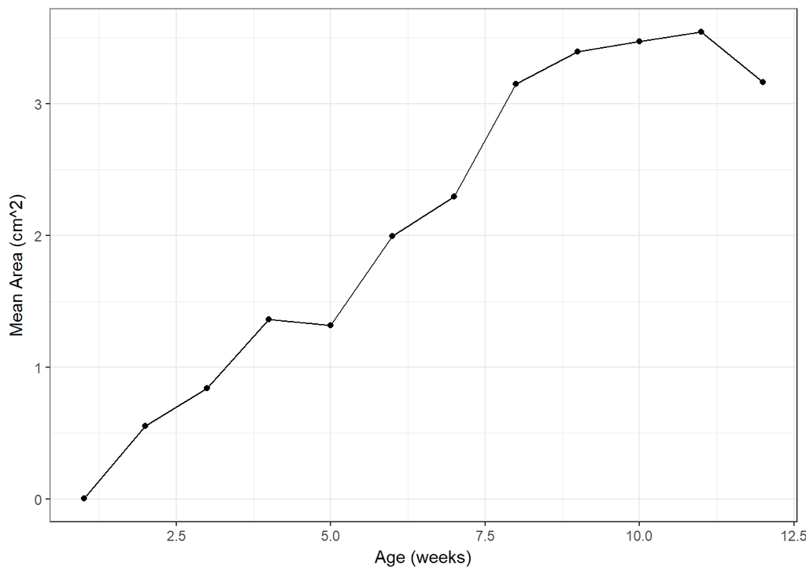

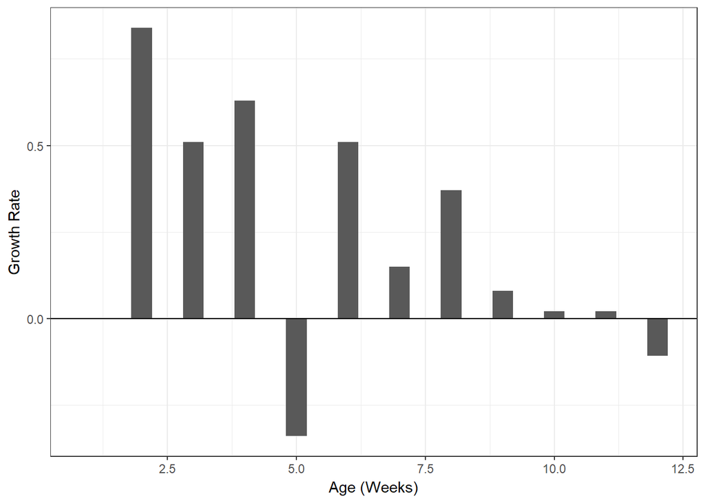

**Time Series Analysis**

Although the data can be visualized as a time series in the above plot, the functionality for analysis is incredibly limited. The data will be converted to an appropriate format for time series analysis with the Zoo, xts, and forecast packages.

```r
library(zoo)
library(xts)
library(forecast)
```

```r
tsmat = data.matrix(meanvec$mean)
idx = as.Date(c("2017-12-28","2018-01-04","2018-01-11","2018-01-18","2018-01-25","2018-02-01","2018-02-08","2018-02-15","2018-02-22","2018-03-01","2018-03-08","2018-03-15"))
matx = xts(tsmat, order.by = idx)
```

**ARIMA Modeling**

The goal of this project was to apply ARIMA modeling to the dataset. However, I was not able to successfully execute it with my data for this project. Assuming it was an issue with my experimental data, I created a new data set modeled off the experimental data for a clean data set. This did not solve the issue. I assume the issue lies in my coding or poor understanding of the concepts. The benefit for ARIMA modeling with my data is real time analysis and forecasting for expected plant growth based on general trends, or cycles in which the mean of my growth data increases and decreases. This could be particularly useful for determining the ideal times to subculture plantlets to maintain as high of vigor as possible. Since this study focuses primarily on establishing a protocol for mass producing plantlets, determining these critical points in the tissue culture process could produce a more informed protocol.

Since I was unable to execute this model with my data, I will go through some of the basic methodology with a preloaded data set.

*Methodology*

Although there are many types of models, I will be doing an ARIMA forecast using the AirPassenger time series data. Here, we can see the time series data and plot. We can fit a line to the data to show the upward trend of the mean.

```r
AirPassengers
```

```
##      Jan Feb Mar Apr May Jun Jul Aug Sep Oct Nov Dec
## 1949 112 118 132 129 121 135 148 148 136 119 104 118
## 1950 115 126 141 135 125 149 170 170 158 133 114 140
## 1951 145 150 178 163 172 178 199 199 184 162 146 166
## 1952 171 180 193 181 183 218 230 242 209 191 172 194
## 1953 196 196 236 235 229 243 264 272 237 211 180 201
## 1954 204 188 235 227 234 264 302 293 259 229 203 229
## 1955 242 233 267 269 270 315 364 347 312 274 237 278
## 1956 284 277 317 313 318 374 413 405 355 306 271 306
## 1957 315 301 356 348 355 422 465 467 404 347 305 336
## 1958 340 318 362 348 363 435 491 505 404 359 310 337
## 1959 360 342 406 396 420 472 548 559 463 407 362 405
## 1960 417 391 419 461 472 535 622 606 508 461 390 432
```

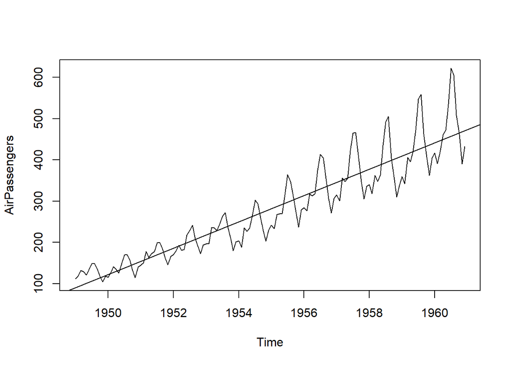

```
## integer(0)
```

```r
plot(AirPassengers)+
abline(reg = lm(AirPassengers ~ time(AirPassengers)))
```

In order to run the model, the variance must be equal and the mean constant. As we can see in the plot, the mean and variance changes over time. We need to equalize the variance and differentiate the mean in order to make it constant.

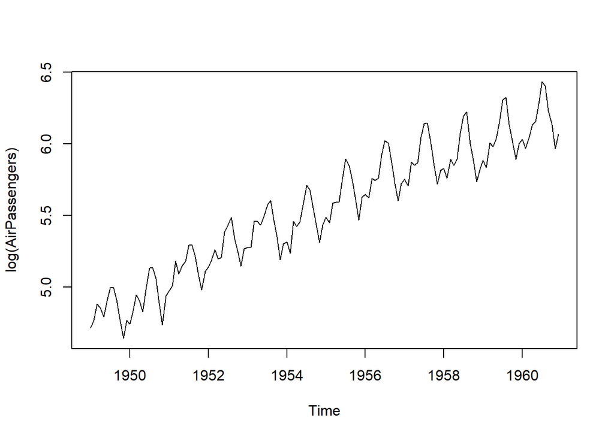

```r
plot(log(AirPassengers))
```

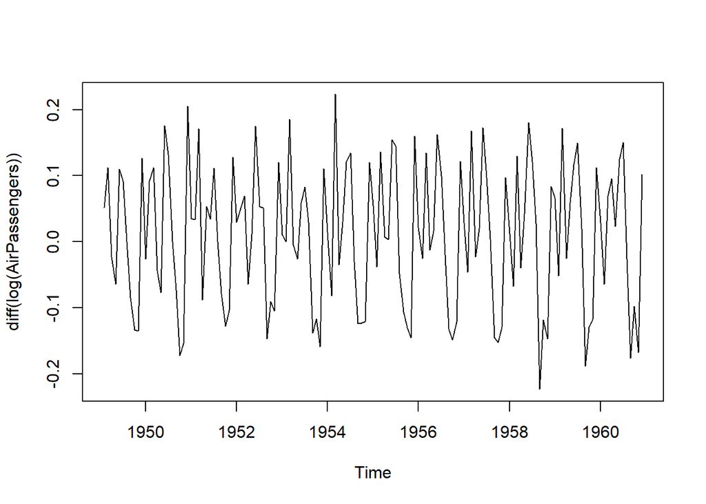

```r
plot(diff(log(AirPassengers)))
```

The next step would be to determine which type of model to fit by determining if the data is stationary or nonstationary. This can be done by running a Dickey-Fuller Test on the data. A P-Value < 0.05 means that the data is stationary, as can be seen below.

```r
library(tseries)
adf.test(diff(log(AirPassengers)), alternative = "stationary")
```

```
##
##  Augmented Dickey-Fuller Test
##
## data:  diff(log(AirPassengers))
## Dickey-Fuller = -6.4313, Lag order = 5, p-value = 0.01
## alternative hypothesis: stationary
```

In order to run the model, values for variables “P”, “d”, and “q” need to be determined using Auto- and Cross- Covariance and Correlation.

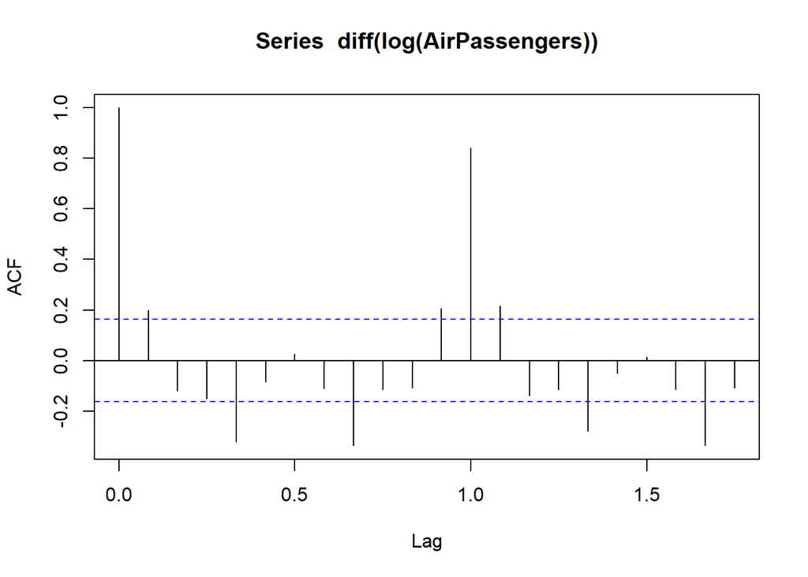

```r
acf(diff(log(AirPassengers)))
```

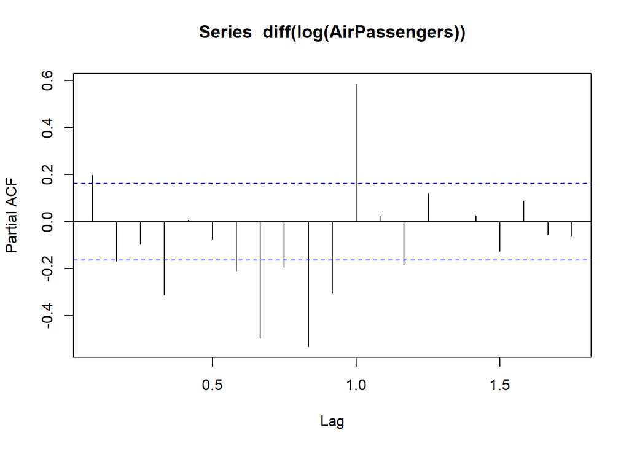

```r
pacf(diff(log(AirPassengers)))
```

```r
d = diff(log(AirPassengers))
```

```r
fit = arima(log(AirPassengers), c(0,1,1), seasonal = list(order = c(0,1,1), period = 12))
pred = predict(fit, n.ahead = 10*12)
pred1 = 2.178^pred$pred
pred1
```

```
##           Jan      Feb      Mar      Apr      May      Jun      Jul
## 1961 116.3045 111.3080 122.0104 124.6586 127.9277 142.2380 158.4316
## 1962 125.3529 119.9677 131.5027 134.3570 137.8804 153.3040 170.7575
## 1963 135.1052 129.3010 141.7335 144.8098 148.6073 165.2310 184.0423
## 1964 145.6163 139.3606 152.7602 156.0759 160.1689 178.0858 198.3606
## 1965 156.9451 150.2027 164.6448 168.2184 172.6299 191.9407 213.7929
## 1966 169.1553 161.8883 177.4540 181.3057 186.0603 206.8735 230.4257
## 1967 182.3154 174.4831 191.2598 195.4111 200.5356 222.9681 248.3527
## 1968 196.4994 188.0577 206.1396 210.6139 216.1371 240.3148 267.6743
## 1969 211.7868 202.6884 222.1771 226.9995 232.9524 259.0111 288.4991
## 1970 228.2637 218.4574 239.4623 244.6598 251.0759 279.1619 310.9441
##           Aug      Sep      Oct      Nov      Dec
## 1961 157.8915 137.4403 125.6042 112.1527 121.6604
## 1962 170.1753 148.1330 135.3761 120.8781 131.1255
## 1963 183.4148 159.6576 145.9082 130.2823 141.3270
## 1964 197.6843 172.0789 157.2597 140.4181 152.3221
## 1965 213.0640 185.4664 169.4944 151.3425 164.1726
## 1966 229.6401 199.8956 182.6809 163.1168 176.9451
## 1967 247.5059 215.4472 196.8933 175.8072 190.7112
## 1968 266.7617 232.2089 212.2114 189.4848 205.5484
## 1969 287.5155 250.2745 228.7213 204.2266 221.5399
## 1970 309.8839 269.7456 246.5156 220.1152 238.7755
```

Based on the parameters established in the prediction, the new data set now has predictive values for 10 years. For my data, this would be a significantly smaller time scale, which is established in the n.ahead function. The time series can also be plotted, with the dash line now indicating predicted values based on the model.

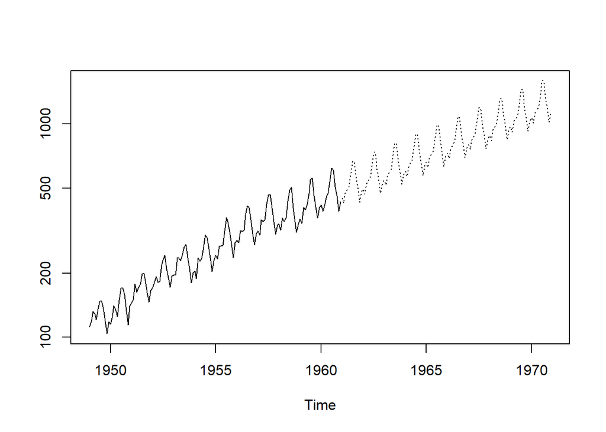

```r
ts.plot(AirPassengers,2.718^pred$pred, log = "y", lty = c(1,3))
```